# Rによる機械学習 ガイダンス

Cho（ztempest0218@gmail.com）

Last Updated: 2026-09-30

**今回の内容**

- この授業の説明（別途のスライドを参照すること） https://docs.google.com/presentation/d/11cHfDtPs2GQI6e_egsXN156vT2dMrYqEZNobzb_hlmo/edit?usp=sharing
- 機械学習とは何か、その三つの分類
- 初めての機械学習

# 1 この授業について

## 1.1 前提となる知識

この授業は、**「特殊講義（Rプログラミング入門）」の続編**である。前期の入門編では、生データを読み込み、加工し、可視化し、回帰分析を行い、レポートとして出力するという一連の流れを学んだ。本科目では、そこで身につけた道具を前提として、**予測（prediction）**という新しい目的のためにデータを扱う。

したがって、以下の内容は既知のものとして進める。復習が必要な者は、入門編の講義資料（下記サイト）を各自で見直しておくこと。 https://ztempest0218.github.io/R-Programming/

| 前提とする内容 | 入門編での該当回 |
| --- | --- |
| R Scriptの作成、working directoryの設定 | 第2回・第5回 |
| ベクトル、data.frame、`[ ]`・`$` による要素の取り出し | 第3回・第4回 |
| `dplyr` によるデータの前処理（パイプ、`filter`、`mutate`、`select`） | 第6回 |
| `ggplot2` による可視化 | 第9回・第10回 |
| `lm()` による回帰分析と係数の解釈 | 第11回 |
| `for` ループによる繰り返し処理 | 第13回 |
| R MarkdownによるレポートのKnit | 第14回 |

機械学習の手法は、「モデルを推定し、設定を少し変えて、もう一度推定する」という作業の繰り返しで成り立っている。このとき、推定の中でデータから自動的に決まる値を**パラメータ**（回帰係数など）、人間が推定の前に指定する設定を**ハイパーパラメータ**（モデルの複雑さを決める設定など）と呼ぶ。そして、このハイパーパラメータを少しずつ変えて、最も良いものを探す作業を**チューニング（tuning）**という。

## 1.2 R・RStudio・GitHub環境構築について

本科目は、**R・RStudio・GitHubがすでに設定済み**であることを前提とする。入門編（Rプログラミング入門）を履修した人は、新たに準備する必要はない。

入門編を履修していない人は、下記の**入門編・第1回ガイダンス**を見て、各自で環境を整えておくこと。R・RStudioのインストール、文字コードの設定、GitHubアカウントの作成まで、すべて手順が載っている。

https://ztempest0218.github.io/R-Programming/001-guidance.html

加えて、課題の提出（push）には**GitHubの2段階認証**の設定が必須である。pushができない原因の大半がこれなので、下記を見て必ず設定しておくこと。

https://drive.google.com/file/d/1l3gKPgRnLeF7Mp9-EoZ6ifHqczD7z6R3/view?usp=sharing

## 1.3 参考文献

特定のテキストは使用せず、毎回資料を配布する。より深く学びたい者には、次の2冊を参考にしてください。

- Lantz, Brett 著／クイープ 訳『Rによる機械学習［第3版］』翔泳社, 2021
- Deisenroth, Faisal, Ong 著『機械学習のための数学』共立出版, 2024

なお、本科目は参考書の章立ての順番どおりには進めない。各回の資料を中心に進めるので、参考書はあくまで補助として使ってほしい。

# 2 機械学習とは

## 2.1 定義

機械学習（machine learning）とは、**データからパターンを学習し、未知のデータに対して予測や判断を行う手法の総称**である。

「学習」という言葉が使われているが、コンピュータが人間のように理解しているわけではない。実際に行われているのは、**ある評価基準（損失関数）を最小にするパラメータを探す**という、純粋な数値最適化である。入門編で学んだ最小二乗法（残差平方和を最小にする係数を探す）も、この意味では機械学習の一手法である。

$$(\hat{\beta}_0,\ \hat{\beta}_1)\ =\
\operatorname*{arg\,min}_{\beta_0,\ \beta_1}\ \sum_{i=1}^{n}\bigl(y_i -
\beta_0 - \beta_1 x_i\bigr)^2$$

右辺の「残差平方和」が損失関数であり、それを最小にする $\beta_0,\beta_1$ を探すのが学習にあたる。得られた $\hat{\beta}_0,\hat{\beta}_1$ が推定された係数である。残差とは、下図のように、各点から回帰直線までの縦方向のズレ（実際の値と予測値の差）のことである。

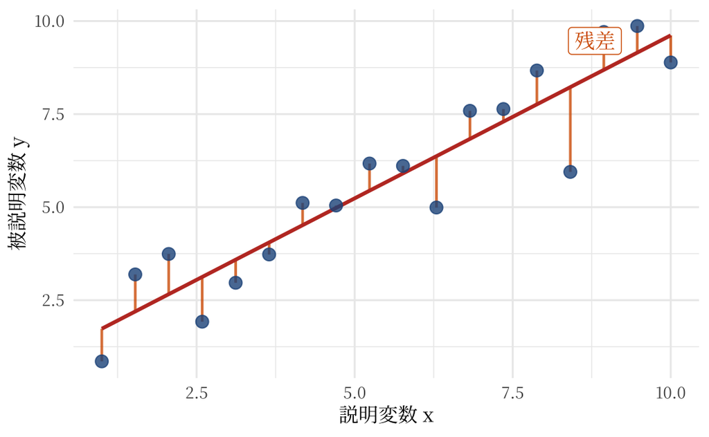

つまり、機械学習は統計学と別物ではなく、すでに知っている回帰分析の延長線上にある。違いは、何を最小化するか、そしてその結果をどう評価するかにある。

## 2.2 三つの分類

機械学習は、扱うデータと目的によって、大きく三つに分類される。区分ごとの考え方を、身近な例で整理すると次のようになる。

| 区分 | データ | 目的 | 身近な例 |
| --- | --- | --- | --- |
| 教師あり学習 | 入力 $X$ と正解 $y$ | $X$ から $y$ を予測する | 物件データから家賃を予測する |
| 教師なし学習 | 入力 $X$ のみ | データの構造を見つける | 顧客を購買傾向で層に分ける |
| 強化学習 | 環境と報酬 | 良い行動を学ぶ | 囲碁AIが勝てる手を学ぶ |

たとえば、入門編で学んだ単回帰

$$y = \beta_0 + \beta_1 x +
\varepsilon$$

は、1つの説明変数 $x$ から数値 $y$ を予測する、最も単純な教師あり学習（回帰）である。

それぞれの区分には、代表的な手法（アルゴリズム）がある。本科目で扱うものを挙げておく。**教師あり学習**には、線形回帰・ロジスティック回帰・k近傍法・決定木・ランダムフォレスト・勾配ブースティング（XGBoost）・サポートベクターマシン（SVM）がある。**教師なし学習**には、k-meansクラスタリング・階層的クラスタリング・主成分分析（PCA）がある。**強化学習**は、本科目ではQ学習など基礎的な考え方のみを扱う。

### 2.2.1 教師あり学習

正解 $y$ つきのデータから、$X$ と $y$ の関係を学ぶ。$y$ が数値なら「回帰」、カテゴリなら「分類」と呼ぶ。有名な例が、**写真が「ネコ」か「イヌ」かを当てる**画像分類である。大量の写真（$X$）と正解ラベル（$y$＝ネコ／イヌ）を与えて学習させ、新しい写真の正解を当てさせる。

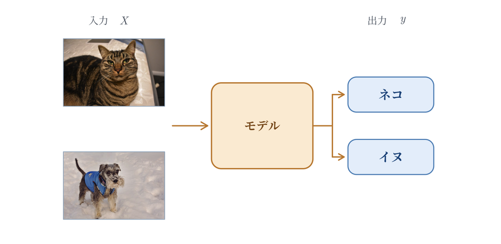

写真の出所：ネコ “Cat” by Burnt Pineapple Productions／イヌ “dog” by krecimag（Flickr）

ただし、画像分類はイメージをつかむための例である。本科目は、入門編で扱ったような**構造化データ**を対象とし、画像そのものは扱わない。

### 2.2.2 教師なし学習

正解 $y$ がなく、入力 $X$ だけからデータの構造を見つける。代表例が、顧客を購買の傾向で**似た者どうしのグループに分ける**クラスタリングである。下の図は、購買傾向の似た顧客がまとまりをつくる様子を示した**クラスタリングのイメージ**である。色は説明のためにあらかじめ付けたもので、クラスタリングの計算結果ではない。

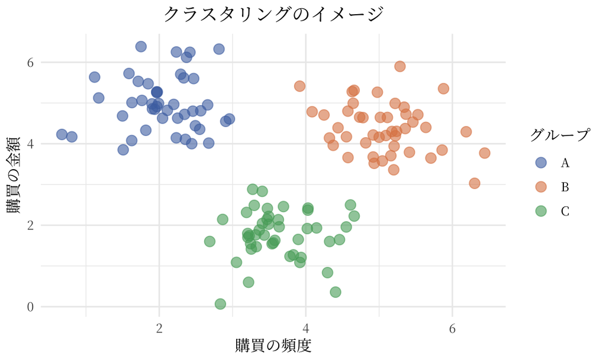

### 2.2.3 強化学習

あらかじめ正解データを与える「教師あり学習」とは異なり、強化学習では**行動の結果として返ってくる報酬**を手がかりに、自律的に学習を進める。正解は与えられず、エージェント（学習する主体）は、行動して報酬を受け取り、より多くの報酬が得られるように行動を改善していく。

代表例が、囲碁AI「**AlphaGo**」である。この場合、**エージェント**はAI、**環境**は碁盤、**行動**は石を置く場所、**報酬**は勝てば $+1$・負ければ $-1$ である。AlphaGoは、人間の棋譜からの学習と自己対戦を組み合わせて、勝ちにつながる手を学んだ。人間の棋譜を使わずに自己対戦から学んだのは、後継のAlphaGo Zeroである。2016年には世界トップ棋士に勝利している。身近なところでは、在庫管理の発注量の調整（在庫切れや過剰在庫のコストが小さいほど報酬が高い）などにも使われる。

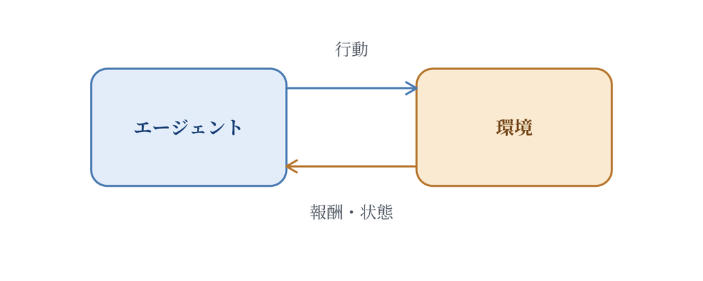

## 2.3 説明・推論と予測：分析の目的による違い

入門編では係数の解釈に注目したが、本科目では**未知のデータに対する予測精度**を重視する。同じ回帰モデルでも、目的によって評価の仕方が変わる。

| 観点 | 説明・推論を目的とする分析 | 予測を目的とする分析 |
| --- | --- | --- |
| 目的 | 変数間の関係や効果を理解する | 未知データを正確に予測する |
| 関心の対象 | 係数 $\hat{\beta}$ と推定の不確実性 | 予測値 $\hat{y}$ と予測誤差 |
| データの使い方 | 分析の仮定や研究設計に応じて推定する | 学習に使わないデータで予測精度を評価する |
| 良いモデルの基準 | 目的に合う仮定のもとで解釈・推論できること | 未知データの予測誤差が小さいこと |

たとえば、教育と賃金のデータでも、「教育を増やすと賃金がどれだけ変わるか」と「ある人の賃金はいくらになりそうか」では問いが違う。前者は因果効果、後者は予測精度に注目する。予測が当たるだけでは因果効果は分からず、因果効果の推定には研究設計や仮定が必要である。

本科目では、**学習に使わなかったデータで、予測がどれだけ当たるか**を確かめる。次の実習で、訓練データとテストデータに分けて試してみよう。

## 2.4 用語の対応（参照用）

入門編で使った用語と、機械学習の資料でよく使う用語をまとめておく。まずは「特徴量＝説明変数」「目的変数・ラベル＝被説明変数」を押さえ、他の用語は必要に応じて参照してほしい。

| 統計学・計量経済学 | 機械学習 | 統計の記号 | 機械学習の記号 |
| --- | --- | --- | --- |
| 被説明変数・従属変数 | 目的変数・ラベル（label） | $y$ | $y$ |
| 説明変数・独立変数 | 特徴量（feature） | $X$ | $X$ |
| 定数項・切片 | バイアス（bias） | $\beta_0$ | $w_0$ |
| 回帰係数・パラメータ | 重み（weight） | $\beta$ | $w$ |
| 観測数（標本の大きさ） | サンプル数 | $n$ | $n$（$m$ と書く本もある） |
| 推定する・あてはめる | 学習する・訓練する（train） |  |  |
| 残差平方和などの最小化 | 損失（loss）の最小化 |  |  |

### 2.4.1 係数と重みの対応

機械学習では、重回帰モデルを次の図のように描くことが多い。説明変数 $x_1,\,x_2$ に加えて、つねに1をとる**バイアス項** $c$ を置き、それぞれに重み $w_0,\,w_1,\,w_2$ を掛けて足し合わせ、被説明変数 $y$ を予測する。

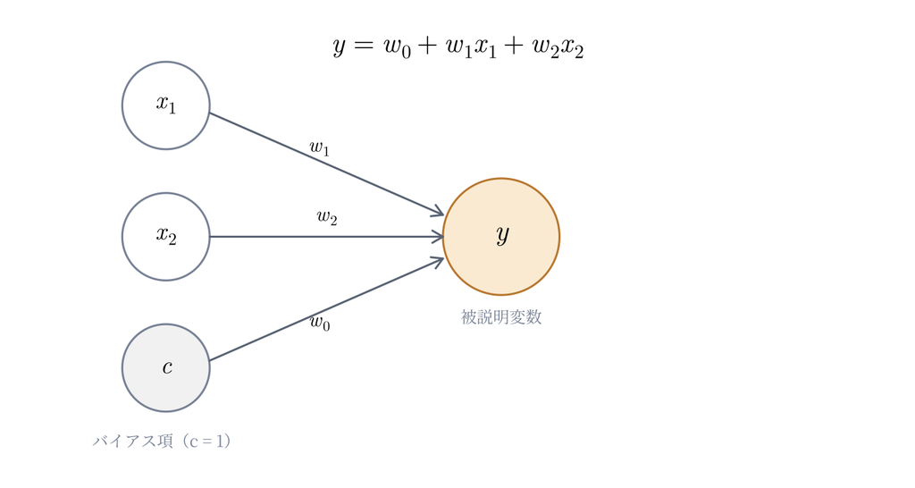

「係数」と「重み」は、この線形モデルでは同じ役割の値を指す。記号を $\beta$ から $w$ に変えても、入力に係数を掛けて足し合わせる計算は同じである。

# 3 初めての機械学習

シミュレーションデータで回帰を復習したあと、未知データでの予測精度を確かめる。単純な直線と複雑な曲線を比べ、過学習を観察しよう。

## 3.1 シミュレーションデータを作る

真の関係が $y = 2 + 0.8\,x$（にノイズを加えたもの）であるデータを30個作る。真の形がこちらに分かっているので、モデルが当たっているかを自分で判定できる。

```r
set.seed(7)
n <- 30
x <- runif(n, 0, 10)
y <- 2 + 0.8 * x + rnorm(n, sd = 1.5)   # 真の関係 + ノイズ
data <- data.frame(x, y)
head(data)
```

|  | x | y |
| --- | --- | --- |
| 1 | 9.8890930 | 10.612795 |
| 2 | 3.9774545 | 3.841263 |
| 3 | 1.1569778 | 2.464590 |
| 4 | 0.6974868 | 2.550756 |
| 5 | 2.4374939 | 5.432241 |
| 6 | 7.9201043 | 9.595709 |

## 3.2 回帰の復習：直線を当てはめる

まず入門編の復習として、手元の30個のデータで直線を当てはめ、**係数の解釈**を確認する。ここでは、自分で設定した真の係数0.8に対して、推定値がどの程度近いかを見る。

```r
fit <- lm(y ~ x, data = data)
summary(fit)   # 回帰結果（係数・標準誤差・t値・p値・R^2）
```

```
##
## Call:
## lm(formula = y ~ x, data = data)
##
## Residuals:
##     Min      1Q  Median      3Q     Max
## -2.0991 -0.8322 -0.1026  1.0344  1.8905
##
## Coefficients:
##             Estimate Std. Error t value Pr(>|t|)
## (Intercept)   2.0065     0.3932   5.102 2.10e-05 ***
## x             0.8064     0.0667  12.090 1.25e-12 ***
## ---
## Signif. codes:  0 '***' 0.001 '**' 0.01 '*' 0.05 '.' 0.1 ' ' 1
##
## Residual standard error: 1.221 on 28 degrees of freedom
## Multiple R-squared:  0.8392, Adjusted R-squared:  0.8335
## F-statistic: 146.2 on 1 and 28 DF,  p-value: 1.249e-12
```

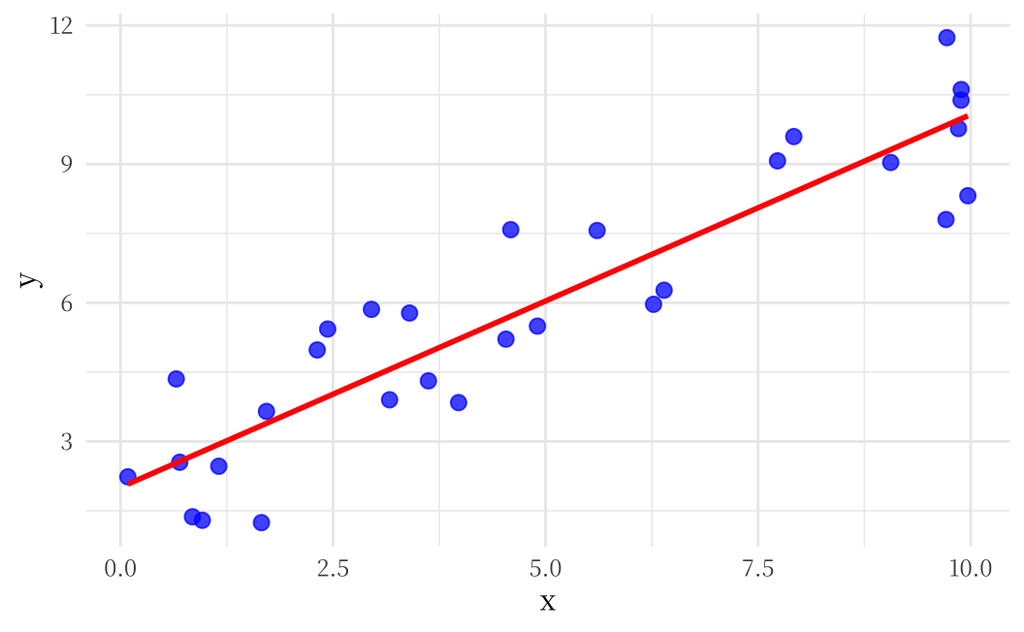

```r
library(ggplot2)

ggplot(data, aes(x, y)) +
  geom_point(color = "blue", alpha = 0.75, size = 2.5) +
  geom_smooth(method = "lm", se = FALSE, color = "red", linewidth = 1) +
  labs(x = "x", y = "y")
```

`Estimate` の傾きは約0.81で、設定した真の値0.8に近い。$x$ が1増えると $y$ の予測値は約0.81増える、と読める。標準誤差やp値の読み方は入門編の第11回を参照してほしい。なお、統計的に有意でないことは、「効果がない」と証明されたことを意味しない。

## 3.3 予測精度に注目する：訓練とテストに分ける

次は、予測を目的として、このモデルが**未知のデータも当てられるか**を問う。これを確かめるために、データを訓練用とテスト用に分ける。

```r
set.seed(1)
idx   <- sample(1:n, size = round(0.7 * n))
train <- data[idx, ]   # 学習に使う
test  <- data[-idx, ]  # 取っておく
```

元のデータの行番号順に、各データがどちらに入ったかを示す。`idx` に含まれる行は train（訓練用）、それ以外は test（テスト用）である。今回は、30件を train 21件・test 9件に分けた。

| 元の行番号 | x | y | データの区分 |
| --- | --- | --- | --- |
| 1 | 9.889 | 10.613 | train（訓練用） |
| 2 | 3.977 | 3.841 | train（訓練用） |
| 3 | 1.157 | 2.465 | test（テスト用） |
| 4 | 0.697 | 2.551 | train（訓練用） |
| 5 | 2.437 | 5.432 | train（訓練用） |
| 6 | 7.920 | 9.596 | test（テスト用） |
| 7 | 3.401 | 5.779 | train（訓練用） |
| 8 | 9.721 | 11.735 | test（テスト用） |
| 9 | 1.659 | 1.245 | train（訓練用） |
| 10 | 4.591 | 7.582 | train（訓練用） |
| 11 | 1.717 | 3.650 | train（訓練用） |
| 12 | 2.315 | 4.980 | train（訓練用） |
| 13 | 7.728 | 9.070 | train（訓練用） |
| 14 | 0.963 | 1.296 | train（訓練用） |
| 15 | 4.534 | 5.213 | train（訓練用） |
| 16 | 0.847 | 1.371 | test（テスト用） |
| 17 | 5.607 | 7.563 | test（テスト用） |
| 18 | 0.087 | 2.236 | train（訓練用） |
| 19 | 9.857 | 9.768 | train（訓練用） |
| 20 | 3.166 | 3.902 | test（テスト用） |
| 21 | 6.394 | 6.272 | train（訓練用） |
| 22 | 2.952 | 5.858 | train（訓練用） |
| 23 | 9.967 | 8.316 | train（訓練用） |
| 24 | 9.060 | 9.035 | test（テスト用） |
| 25 | 9.887 | 10.382 | train（訓練用） |
| 26 | 0.656 | 4.353 | test（テスト用） |
| 27 | 6.270 | 5.967 | train（訓練用） |
| 28 | 4.905 | 5.496 | train（訓練用） |
| 29 | 9.710 | 7.801 | test（テスト用） |
| 30 | 3.622 | 4.311 | train（訓練用） |

**テストデータの結果を繰り返し見ながら、モデルや設定を調整してはいけない**。それをすると、テストデータに合わせた調整になり、未知データでの予測精度を公平に評価できなくなる。調整用のデータをどう分けるかは、次回扱う。今回は、あらかじめ決めた二つのモデルを使い、過学習の例を確認する。

訓練データだけで学習し、テストデータで予測誤差（RMSE、小さいほど良い）を見る。RMSEなど予測精度の指標の詳しい話は、次回の講義で扱う。ここでは、**単純なモデル（直線）**と**複雑なモデル（9次の多項式）**を比べる。

```r
rmse <- function(a, b) sqrt(mean((a - b)^2))

simple  <- lm(y ~ x, data = train)
complex <- lm(y ~ poly(x, 9), data = train)

# 訓練データでの誤差
c(simple  = rmse(train$y, predict(simple)),
  complex = rmse(train$y, predict(complex)))
```

```
##    simple   complex
## 1.1047895 0.6933207
```

```r
# テストデータでの誤差
c(simple  = rmse(test$y, predict(simple,  newdata = test)),
  complex = rmse(test$y, predict(complex, newdata = test)))
```

```
##   simple  complex
## 1.346815 5.414424
```

訓練データとテストデータのRMSEをまとめると、次のようになる。

| モデル | 訓練データのRMSE | テストデータのRMSE |
| --- | --- | --- |
| 直線 | 1.105 | 1.347 |
| 9次多項式 | 0.693 | 5.414 |

複雑なモデルは、**訓練データでは誤差が小さい**。当てはまりだけ見れば、単純なモデルより「良い」。ところが**テストデータでは誤差がはるかに大きく**なる。図にすると一目でわかる。

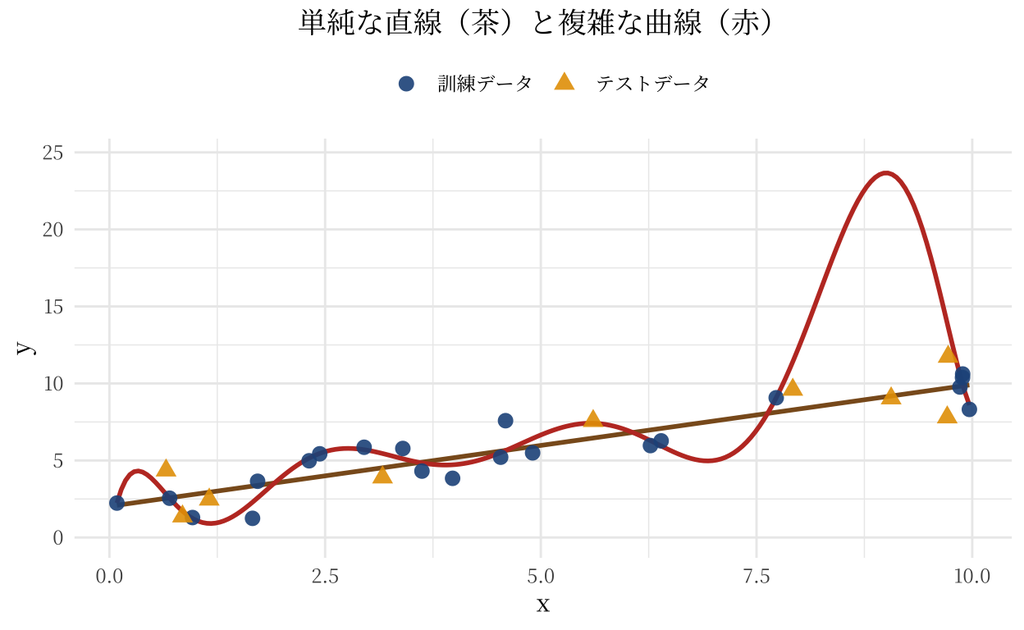

複雑なモデルは、訓練データの点を無理に通ろうとしてうねり、見ていないデータを大きく外す。これが**過学習（overfitting）**である。

過学習とは、モデルが訓練データに合わせすぎて、ノイズ（偶然のばらつき）まで学んでしまう状態である。訓練データにはよく当てはまるのに、新しいデータでは予測が外れる。当てはまりではなくテストでの予測精度を見るのは、この過学習を見抜くためである。モデルは複雑なほど良いわけではない。